# Milestone

*Disa Sariola, CMPS 6790 Tulane Fall 2023* https://alexandrasar.github.io/CMPS6790_Project/

This project is done partly based on my RA duties for the Center for Community-Engaged AI, and the primary data source is not open source but can be requested from the authors of the paper. All related work and code are hosted on a private github page, to which Professor Mattei has rights to. I am working alone for this Fall 2023 Data Science Project.

## Callback Rates and Unemployment in 11 States

### About the Data

The motivations for these projects are tied directly to my position as an RA for the CCEAI. This project is based on four different data sources. The main dataset is from the paper *‘Is It Harder for Older Workers to Find Jobs? New and Improved Evidence from a Field Experiment’* (1). The data enrichment is done with *State Unemployment Percentage* (2), *GeoPy Nonimatim* (3) and *Age Discrimination Laws per state from the paper "Do State Laws Protecting Older Workers from Discrimination Reduce Age Discrimination in Hiring? Evidence from a Field Experiment"* (4). As a note (4) was manually interpreted from the page 16 table on these laws, and binary encoded. For further insights, that csv file can be found in the data folder under the name *'StateLawsAge.csv"* The main dataset contains 40,208 resume applications, that were generated for a correspondence study to uncover age discrimination in job application. These resumes are based on real world resumes, and more information on their generation process can be found in (1). These resumes were used to apply to real job applications across 11 states, and each application was done in sets of three, one from each agegroup. So for each ad, three comparable applications were sent, their only notable difference was the age of the applicant. Hence, the generated resumes have been formulated to have as many controlled variables as possible, and to seem as realistic as possible. Each resume contains the applicants name, age, contact information, the job they applied to, their skill level, educational background, special skills, city and whether they got a callback. For each application, the main measurement (and in this analysis case the target variable to predict) is whether the applicant (resume) received a callback.

The unemployment percentage data is from the bureau of labor statistics and contains the employment and unemployment percentage for each respective state for each year. As the main data concerns only 2015, that is the only year that is appended to the data.

GeoPy Nonimatim is used to fetch the state for each city, as the resume applications contain only the city where the application was made. As the application corresponds to the location of the applicant, we only need to fetch one states information per application.

The final enrichment dataset is from the paper *"Do State Laws Protecting Older Workers from Discrimination Reduce Age Discrimination in Hiring? Evidence from a Field Experiment"* (4), and were manually extracted and then encoded to be categorical and binary.

### Research Questions, Treatments, and Measures

- 1.Is there a relationship between the age group and callbacks?
- 2.Can we predict callbacks, and how accurately can we do this?
- 3.Does age affect the callback prediction between the groups?
- 4.How can we make the callback rates fair between the groups?

The data was divided into an 80/20 split, with 20% as testing data that contains the original distribution of the data. This is done using stratified sampling. The remaining 80% is divided into several datasets to train Logistic Regression, Random Forest and MLP classifiers on. Each classifier was trained with the five datasets.

#### Treatments

##### Base Rate (BR)

- Original data distribution

##### Fewer Young/Middle (FWYM)

- Randomly delete young/middle-aged people, at 30%.

##### Equalized Base Rate (EBR)

- Randomly delete old people that did not get a callback, so that the callback rate matches that of young/middle.

##### Higher Base Rate Difference (HBRD)

- Randomly delete young/middle-aged people that did not get a callback, at 30%, so that the callback rate matches that of old.

##### Balanced outcomes (BO)

- Down sample young and middle age groups so that the number of callbacks matches that of old people.

There are five measurements used for each of these five sets, to measure the level of bias for each group. These are from the papers (6) and (7). The notation $_(ym)$ refers to tthe combined age group of young and middle. Meanwhile, the notation $ _(old) $ refers to the old age group. All measures are done as the difference between the results of these two groups.

#### Measures

##### Demographic Parities

- Receiving positive outcomes at the same rate, so $ \frac{(TP_(old)+FP_(old))}{(TP_(old)+FP_(old)+FN_(old)+TN_(old))} - \frac{(TP_(ym)+FP_(ym))}{(TP_(ym)+FP_(ym)+FN_(ym)+TN_(ym))} $

##### Demographic Parities Gap

- The division of accurate outcomes between the two groups $ \frac{(TP_(old)+TN_(old))} {(TP_(old)+FP_(old)+FN_(old)+TN_(old))} - \frac{(TP_(ym)+TN_(ym))}{(TP_(ym)+FP_(ym)+FN_(ym)+TN_(ym))} $

##### Equalized Odds

- Equal True Positive and False Positive rates between the two different groups match, so $ \frac{(TP_(old))}{(TP_(old)+FP_(old)+FN_(old)+TN_(old))} - \frac{(TP_(ym))}{(TP_(ym)+FP_(ym)+FN_(ym)+TN_(ym))} $ and $ \frac{(FP_(old))}{(TP_(old)+FP_(old)+FN_(old)+TN_(old))} - \frac{(FP_(ym))}{(TP_(ym)+FP_(ym)+FN_(ym)+TN_(ym))} $

##### Predictive Rate Parity

- Whether a classifiers precision rates are equivalent for subgroups under consideration.

##### AUC-ROC

- AUC (Area Under The Curve) ROC (Receiver Operating Characteristics) curve.

The aim here is to see how strong the effet of age is on the callback rates, how do rebalancing and data manipulationg affect the learning outcomes for Logistic Regression, Random Forest and MLP. These three ML models were chosen to be able to compare between treatments and measures more accurately, and to balance the effect of the model.

(1) https://www.journals.uchicago.edu/doi/10.1086/701029

(2) https://www.bls.gov/web/laus/laumstrk.htm

(3) https://geopy.readthedocs.io/en/stable/

(4) https://www.journals.uchicago.edu/doi/epdf/10.1086/704008

(5) https://goelnaman.github.io/upload/doc/papers/2022/li_goel_ash_aies22.pdf

(6) https://arxiv.org/abs/1104.3913

(7) https://jmlr.org/papers/volume23/21-1427/21-1427.pdf

```python
import sys
from scipy import stats
import os
import pandas as pd


#This is the part where we run some basic cleaning and data enriching, to add the state
script_directory = os.getcwd() #get out current working directory, more reliable than appending absolute path
if script_directory+ '\\scripts\\' not in sys.path:
    sys.path.insert(0, script_directory + '\\scripts\\') #Import our helper scripts

from helper_scripts import *

pd.options.mode.chained_assignment = None  # default='warn'
#Above is to remove false positive assignment errors
```

```python
data = pd.read_csv(script_directory + '\\Data\\unemployment_with_state_nora.csv')

data.head()
```

|  | Unnamed: 0 | jobid | dateposted | datesent | timesent | craigslistsubmarket | tripletfolder | companyname | adtitle | documentsthatwererequested | ... | middlestrong | oldstrong | agegroup | middlemale | oldmale | middlefemale | oldfemale | clusterid | spamad | _merge |
| --- | --- | --- | --- | --- | --- | --- | --- | --- | --- | --- | --- | --- | --- | --- | --- | --- | --- | --- | --- | --- | --- |
| 0 | 0 | 1.0 | 5/18/2015 | 42147.0 | 13:33 | westside-southbay | 18.0 | NaN | ÊAdministrative Assistant, Leading Media Firm ... | buzzwords | ... | 0.0 | 0.0 | 1.0 | 0.0 | 0.0 | 0.0 | 0.0 | 1 | 0 | master only (1) |
| 1 | 1 | 1.0 | 5/18/2015 | 42145.0 | 18:47 | westside-southbay | 18.0 | NaN | ÊAdministrative Assistant, Leading Media Firm ... | buzzwords | ... | 0.0 | 1.0 | 3.0 | 0.0 | 0.0 | 0.0 | 1.0 | 1 | 0 | master only (1) |
| 2 | 2 | 1.0 | 5/18/2015 | 42146.0 | 12:22 | westside-southbay | 18.0 | NaN | ÊAdministrative Assistant, Leading Media Firm ... | buzzwords | ... | 0.0 | 1.0 | 3.0 | 0.0 | 0.0 | 0.0 | 1.0 | 1 | 0 | master only (1) |
| 3 | 3 | 4865393.0 | 1/27/2015 | 42031.0 | 7:15:00 AM | Broward County | 27.0 | Furniture Store | SALES ASSOCIATE DESIGNER - PART TIME (fort lau... | NaN | ... | 1.0 | 0.0 | 2.0 | 1.0 | 0.0 | 0.0 | 0.0 | 4865393 | 0 | matched (3) |
| 4 | 4 | 4865393.0 | 1/27/2015 | 42031.0 | 12:00:00 AM | Broward County | 27.0 | Furniture Store | SALES ASSOCIATE DESIGNER - PART TIME (fort lau... | NaN | ... | 0.0 | 0.0 | 1.0 | 0.0 | 0.0 | 0.0 | 0.0 | 4865393 | 0 | matched (3) |

5 rows × 138 columns

Above is the raw data, which has 138 columns. From a cursory glance, it can be seen that the data is not very neat and there is a lot of redundant data. There are multiple dummy columns - for example the age group, and separate *'middlemale', 'oldmale', 'oldfemale', 'middlefemale'* and many others. This pattern of extra columns and irregular format is consistent in the data, so the first step is to clean these up.

As can be seen, the adtititles are in need of cleaning, and as aforementioned there are some duplicate columns, and irrelevant columns that need to be dropped. We also combine some of the columns, to remove redundancy. The columns that are used in the end are *'state', 'zipcode','city','agegroup', 'gender', 'employment', 'occupation','template', 'spanish','extra_qualifs', 'internshipflag', 'customerservice', 'cpr', 'techskills', 'wpm', 'grammar', 'college', 'employeemonth', 'volunteer', 'skill', 'callback', 'adtitle'*. There is also the question of missing data, as the data has the city, but no state. So we use geopy Nonimatim to add the state based on the city. We need to create dummies later to be able to run the ML models, but at the moment we are just striving for a clean dataset that can be used for different purposes. Further cleaning and its details can be found in the *helper_scripts.py* that is imported in the beginning.

```python
agedisc_data = pd.read_csv(script_directory+'\Data\StateLawsAge.csv')
agedisc_data.head()
```

|  | State | City | ADL Minimum Firm Size | ADL Larger Damages than ADEA | DDL Minimum Firm Size | DDL Larger Damages than ADA | DDL Broader Definition of Disability |
| --- | --- | --- | --- | --- | --- | --- | --- |
| 0 | Alabama | Birmingham | 2 | 0 | 0 | 0 | 0 |
| 1 | Alaska | Anchorage | 1 | 1 | 1 | 1 | 0 |
| 2 | Arizona | Phoenix | 2 | 0 | 2 | 0 | 0 |
| 3 | Arkansas | Little Rock | 0 | 0 | 1 | 0 | 0 |
| 4 | California | Los Angeles | 1 | 1 | 1 | 1 | 1 |

Above are the state laws for age discrimination.

The additional data enrichement is done with *State laws for Age Discrimination*. This data can be found in (4) in table form, as was aforementioned - that data was manually parsed into a csv, and then encoded into categorical and binary form depending on the column.

Additionally, this dataset was enriched with the unemployment percentages for each state. These extra columns are *'hs_diploma_state', 'college_diploma_state', 'some_college_state','unemployment_perc', 'ADL Minimum Firm Size', 'ADL Larger Damages than ADEA', 'DDL Minimum Firm Size','DDL Larger Damages than ADA','DDL Broader Definition of Disability'*.

These correspond to the the rate of high school graduation, college graduation rate, college attendance rate, state unemployment percentage, the minimum firm size for the age discrimination laws to apply, whether these ADL damages are larger than The Age Discrimination in Employment Act damages, Disability Discrimination Act Damages larger than ADA, and whether DDL has a broader definition of disability. As a precursor here it is important to remember the state vs. federal laws. While there are federal level laws, state laws might be more punitive.

### Data Analysis

In the above cell the data is cleaned and a supplementary csv is generated, it contains state employment data, callbacks, and occupations. After this, the underlying distribution and some exploratory analysis is required. The following graphs visualize the frequency of callbacks for each occupation, state, and applicant employment status. Also graphs to show some interaction between the variable of age and callbacks.

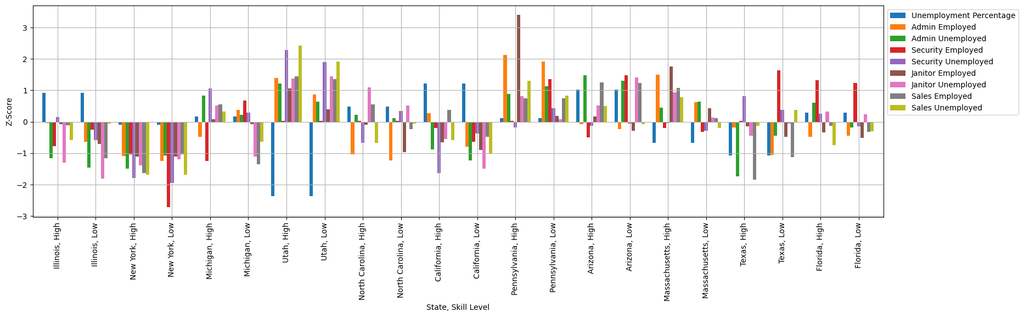

```python
df = pd.read_csv(script_directory +'/Data/unemployment_percentage_state.csv')
#We z-score here, as we dont care to save the z-scored data
for column in df.columns[1:]:
    df[column] = stats.zscore(df[column])

ax = df.plot(x='State', figsize=(20,5),grid=True, width=0.8,  kind='bar', xlabel ='State, Skill Level', ylabel='Z-Score').legend(bbox_to_anchor=(1, 1))
fig = ax.get_figure()
fig.savefig(script_directory + '//Figures//unemployment_percentage_state.png')
```

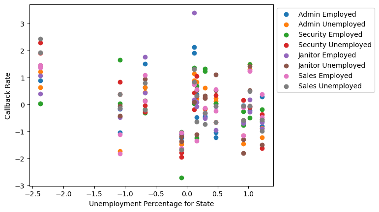

```python
fig = plt.figure()
ax = fig.add_subplot(1, 1, 1)
for column in df.columns[2:]:
    ax.scatter(df['Unemployment Percentage'], df[column], label =column)
ax.set_ylabel('Callback Rate')
ax.legend(bbox_to_anchor=(1, 1))
ax.set_xlabel('Unemployment Percentage for State')
```

The above two graphs show the z-scored callback rates per employment sector per state, the first one shows bars and we separate state and skill levels. The second graph takes across all states and just shows the general z-scored distribution for the data, to give more emphasis on the relationship between the unemployment percentage and the callback rates. By z-scoring the unemployment data, we can see that when we compare a states statistics to the mean, that among the states we have multiple outliers. However, we can only really make some assumptions based on these and we can not comment on the causation of these deviations.

For **Graph 1**, the unemployment percentage on the y-axis being negative is desirable as it means the states unemployment percentage is lower than the mean. Meanwhile, for the callback rates on the y-axis, a positive value is more desirable. There does not seem to be a clear indication that the unemployment percentage has a relationship with the number of callback received. We can see that between states, the labor market is very different, for example Pennsylvania there seems to be a high demand for highly educated employed administrative personnel. In New York, despite a higher education it is much more difficult and unlikely to receive a callback. For Utah, an applicant is more likely to receive a callback no matter the education level.

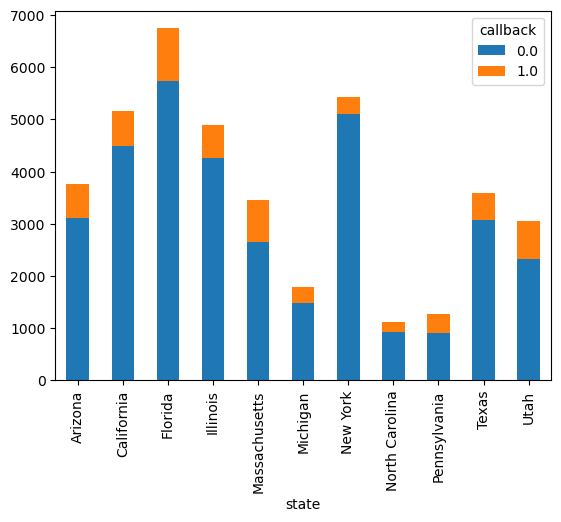

```python
df = pd.read_csv(script_directory +'/Data/unemployment_with_state.csv')
stacked = df.groupby(['state', 'callback']).size()

stacked.unstack().plot(kind='bar', stacked=True)
```

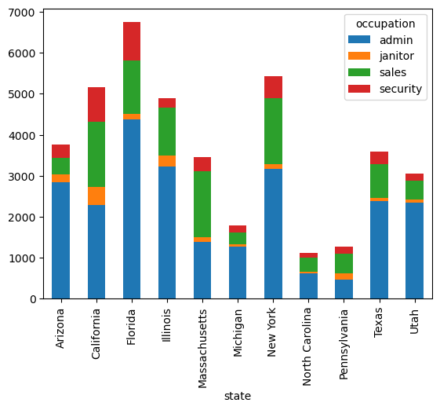

```python
stacked = df.groupby(['state', 'occupation']).size()

stacked.unstack().plot(kind='bar', stacked=True)
```

The First of the above graphs show the distribution of callbacks in a stacked barplot per state irregardless of education, field, or unemployment levels. The second one does the same, but instead of showing the portion of callbacks, we show the distribution of application fields. As can be seen, for most states admin jobs had most applications, and that the overall number of applications varied between the states. Florida had the most applications, and North Carolina had the least. Janitorial positions received the least applications.

As can be seen, the data is currently very heavy on the no-callbacks. This means we have to rebalance the set, so any learning can be validated. The choice here is to for now do random sampling, as the data contains 3 applications for each job. So, we resample with two criteria and also use the original dataset. Below is the original dataset and its distribution of callbacks across all applications.

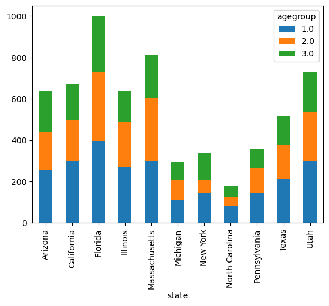

```python
callbacks = df.loc[df['callback'] == 1.0]
stacked = callbacks.groupby(['state', 'agegroup']).size()

stacked.unstack().plot(kind='bar', stacked=True)
```

The above stacked barplot shows the number of callbacks for each age group, 1.0 is young people, 2.0 the middle group and 3.0 is the old age group. Note that this is number, not the percentage. Hence, the number of applications for each age group is not taken into account.

### Machine Learning

```
Logistic Regression when we just remove age.

Statistics for Logistic Regression:
True Positive(TP)  =  9
False Positive(FP) =  2
True Negative(TN)  =  6801
False Negative(FN) =  1226
Cross Validate 5-fold :
[0.84825871 0.84763682 0.84452736 0.84691973 0.847542  ]
Cross Validate 5-fold :
[0.85074627 0.84701493 0.84577114 0.84825871 0.84452736 0.84452736
 0.84328358 0.84825871 0.84433375 0.85180573]
```

```
Accuracy of the binary classifier = 0.847
```

```
Statistics for Random Forest:
True Positive(TP)  =  111
False Positive(FP) =  236
True Negative(TN)  =  6567
False Negative(FN) =  1124
Cross Validate 5-fold :
[0.82338308 0.81218905 0.8159204  0.80771624 0.81393902]
Cross Validate 5-fold :
[0.81716418 0.82338308 0.80845771 0.81094527 0.81716418 0.81343284
 0.81218905 0.81840796 0.81444583 0.81693649]
```

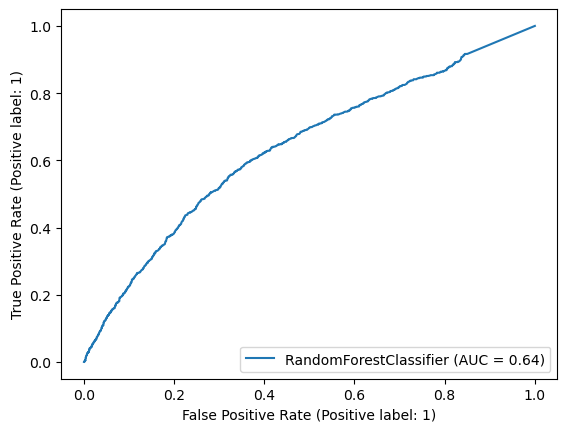

```
Accuracy of the binary classifier = 0.831

Statistics for MLP:
True Positive(TP)  =  86
False Positive(FP) =  154
True Negative(TN)  =  6649
False Negative(FN) =  1149
Cross Validate 5-fold :
[0.82773632 0.82400498 0.81467662 0.81891724 0.84878656]
Cross Validate 5-fold :
[0.82711443 0.83333333 0.81965174 0.81343284 0.80597015 0.8159204
 0.81965174 0.83208955 0.8256538  0.81444583]
```

```
Accuracy of the binary classifier = 0.838
```

```python
print('Logistic Regression when we just remove age.')
analytics_0 = run_ML(df)
```

```
Statistics for Logistic Regression:
True Positive(TP)  =  9
False Positive(FP) =  2
True Negative(TN)  =  6801
False Negative(FN) =  1226
Cross Validate 5-fold :
[0.84825871 0.84763682 0.84452736 0.84691973 0.847542  ]
Cross Validate 5-fold :
[0.85074627 0.84701493 0.84577114 0.84825871 0.84452736 0.84452736
 0.84328358 0.84825871 0.84433375 0.85180573]
```

```
Accuracy of the binary classifier = 0.847
```

```
Statistics for Random Forest:
True Positive(TP)  =  116
False Positive(FP) =  235
True Negative(TN)  =  6568
False Negative(FN) =  1119
Cross Validate 5-fold :
[0.82835821 0.80970149 0.81654229 0.80958307 0.81518357]
Cross Validate 5-fold :
[0.81716418 0.82089552 0.81218905 0.81343284 0.8159204  0.80970149
 0.80721393 0.8159204  0.80821918 0.81195517]
```

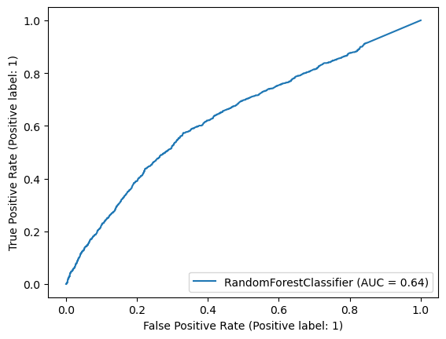

```
Accuracy of the binary classifier = 0.832

Statistics for MLP:
True Positive(TP)  =  86
False Positive(FP) =  154
True Negative(TN)  =  6649
False Negative(FN) =  1149
Cross Validate 5-fold :
[0.82773632 0.82400498 0.81467662 0.81891724 0.84878656]
Cross Validate 5-fold :
[0.82711443 0.83333333 0.81965174 0.81343284 0.80597015 0.8159204
 0.81965174 0.83208955 0.8256538  0.81444583]
```

```
Accuracy of the binary classifier = 0.838
```

```python
analytics_2 = run_ML(df, remove_age = (2.0, 1.0), perc =0.3)
```

```
Statistics for Logistic Regression:
True Positive(TP)  =  9
False Positive(FP) =  2
True Negative(TN)  =  6801
False Negative(FN) =  1226
Cross Validate 5-fold :
[0.84825871 0.84763682 0.84452736 0.84691973 0.847542  ]
Cross Validate 5-fold :
[0.85074627 0.84701493 0.84577114 0.84825871 0.84452736 0.84452736
 0.84328358 0.84825871 0.84433375 0.85180573]
```

```
Accuracy of the binary classifier = 0.847
```

```
Statistics for Random Forest:
True Positive(TP)  =  111
False Positive(FP) =  245
True Negative(TN)  =  6558
False Negative(FN) =  1124
Cross Validate 5-fold :
[0.82400498 0.81467662 0.81654229 0.81082763 0.81144991]
Cross Validate 5-fold :
[0.8159204  0.83084577 0.81467662 0.81467662 0.81840796 0.81094527
 0.80845771 0.81467662 0.81444583 0.81070984]
```

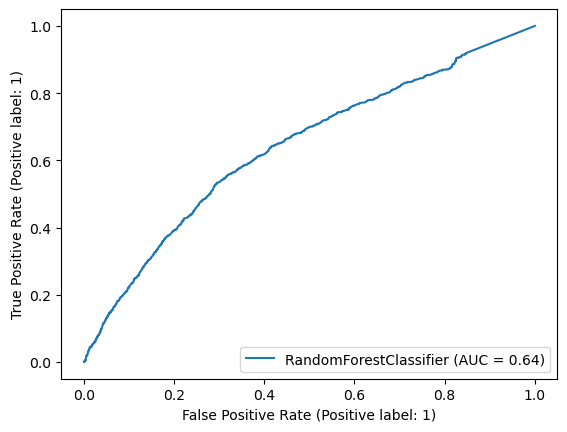

```
Accuracy of the binary classifier = 0.830

Statistics for MLP:
True Positive(TP)  =  86
False Positive(FP) =  154
True Negative(TN)  =  6649
False Negative(FN) =  1149
Cross Validate 5-fold :
[0.82773632 0.82400498 0.81467662 0.81891724 0.84878656]
Cross Validate 5-fold :
[0.82711443 0.83333333 0.81965174 0.81343284 0.80597015 0.8159204
 0.81965174 0.83208955 0.8256538  0.81444583]
```

```
Accuracy of the binary classifier = 0.838
```

```python
analytics_5 = run_ML(df,eq_base_rate= True)
```

```
Statistics for Logistic Regression:
True Positive(TP)  =  9
False Positive(FP) =  2
True Negative(TN)  =  6801
False Negative(FN) =  1226
Cross Validate 5-fold :
[0.84825871 0.84763682 0.84452736 0.84691973 0.847542  ]
Cross Validate 5-fold :
[0.85074627 0.84701493 0.84577114 0.84825871 0.84452736 0.84452736
 0.84328358 0.84825871 0.84433375 0.85180573]
```

```
Accuracy of the binary classifier = 0.847
```

```
Statistics for Random Forest:
True Positive(TP)  =  122
False Positive(FP) =  247
True Negative(TN)  =  6556
False Negative(FN) =  1113
Cross Validate 5-fold :
[0.82587065 0.81778607 0.81778607 0.81082763 0.81207218]
Cross Validate 5-fold :
[0.81716418 0.83084577 0.80721393 0.8159204  0.8159204  0.81094527
 0.80970149 0.82089552 0.80199253 0.80821918]
```

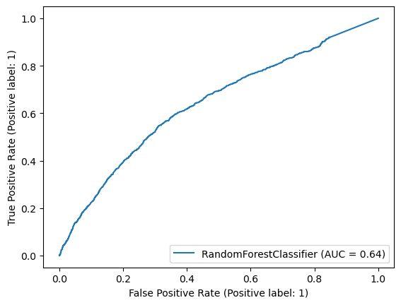

```
Accuracy of the binary classifier = 0.831

Statistics for MLP:
True Positive(TP)  =  86
False Positive(FP) =  154
True Negative(TN)  =  6649
False Negative(FN) =  1149
Cross Validate 5-fold :
[0.82773632 0.82400498 0.81467662 0.81891724 0.84878656]
Cross Validate 5-fold :
[0.82711443 0.83333333 0.81965174 0.81343284 0.80597015 0.8159204
 0.81965174 0.83208955 0.8256538  0.81444583]
```

```
Accuracy of the binary classifier = 0.838
```

```python
analytics_6 = run_ML(df,hi_base_rate= True)
```

```
Statistics for Logistic Regression:
True Positive(TP)  =  9
False Positive(FP) =  2
True Negative(TN)  =  6801
False Negative(FN) =  1226
Cross Validate 5-fold :
[0.84825871 0.84763682 0.84452736 0.84691973 0.847542  ]
Cross Validate 5-fold :
[0.85074627 0.84701493 0.84577114 0.84825871 0.84452736 0.84452736
 0.84328358 0.84825871 0.84433375 0.85180573]
```

```
Accuracy of the binary classifier = 0.847
```

```
Statistics for Random Forest:
True Positive(TP)  =  114
False Positive(FP) =  239
True Negative(TN)  =  6564
False Negative(FN) =  1121
Cross Validate 5-fold :
[0.82400498 0.8159204  0.8159204  0.81269446 0.81518357]
Cross Validate 5-fold :
[0.8159204  0.83084577 0.81467662 0.81218905 0.82089552 0.8159204
 0.80845771 0.82089552 0.81693649 0.81569116]
```

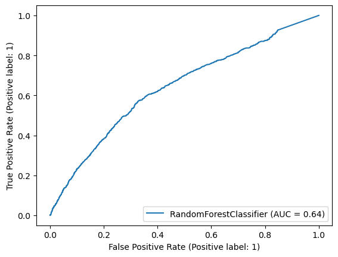

```
Accuracy of the binary classifier = 0.831

Statistics for MLP:
True Positive(TP)  =  86
False Positive(FP) =  154
True Negative(TN)  =  6649
False Negative(FN) =  1149
Cross Validate 5-fold :
[0.82773632 0.82400498 0.81467662 0.81891724 0.84878656]
Cross Validate 5-fold :
[0.82711443 0.83333333 0.81965174 0.81343284 0.80597015 0.8159204
 0.81965174 0.83208955 0.8256538  0.81444583]
```

```
Accuracy of the binary classifier = 0.838
```

```python
analytics_7 = run_ML(df,balanced_outcomes= True)
```

```python
def analytics(analytics_dict):
    """demographic parity ; receiving positive outcomes at the same rate,
    the demographic parity gap; difference in the two groups parities,
    the accuracy parity ; the division of accurate outcomes between the two groups,
    equalized odds ; that equal true positive and false positive rates between the two different groups match,
    predictive rate parity; whether a classifiers precision rates are equivalent for subgroups under consideration.
    """
    keys_t = ''
    keys = ''
    dp_str = ''
    for key_t in analytics_dict.keys():
        keys_t += '\t' + key_t
        model_dict = analytics_dict[key_t]
        ti_k = '\t '

        for key in model_dict.keys():
            ti_k += f'{key_t} {key} {key_t} \t'
            dp_str +=  f' {key_t} {key}: {np.round(model_dict[key]["dp_parity"], 3)},\t'
        dp_str+= '\n'
    print('Demographic parities')
    print('Receiving positive outcomes at the same rate (difference in the two groups parities) -- Equal Positive Prediction Rates ')
    print(keys)
    print(dp_str)


    dp_str_gp = ''
    for key_t in analytics_dict.keys():
        model_dict = analytics_dict[key_t]

        for key in model_dict.keys():
            ti_k += f'{key_t} {key} {key_t} \t'
            dp_str_gp +=  f'{key_t} {key}: {np.round(model_dict[key]["dp_parity_gap"], 3)}: \t'
        dp_str_gp += '\n'
    print('\nDemographic parities gap for', key_t)
    print('The division of accurate outcomes between the two groups')
    print('\t', keys)
    print(dp_str_gp)

    dp_str_TP = ''
    dp_str_FP = ''
    for key_t in analytics_dict.keys():
        model_dict = analytics_dict[key_t]

        for key in model_dict.keys():
            dp_str_TP += f'TP {key_t} {key}: {np.round(model_dict[key]["TP_dif"], 3)} , '
            dp_str_FP += f'FP {key_t} {key}: {np.round(model_dict[key]["FP_dif"], 3)} , '
        dp_str_TP += '\n'
        dp_str_FP += '\n'
    print('\nEqualised Odds')
    print('Equal true positive and false positive rates between the two different groups match')
    print('\t', keys)
    print(dp_str_TP, '\n', dp_str_FP)

    dp_str_precision = ''
    for key_t in analytics_dict.keys():
        model_dict = analytics_dict[key_t]

        for key in model_dict.keys():
            dp_str_precision += f'{key} {key_t}: {np.round(model_dict[key]["PPR"], 3)}'
        dp_str_precision += '\n'
    print('\nPredictive Rate Parity')
    print('Whether a classifiers precision rates are equivalent for subgroups under consideration. ')
    print('\t', keys)
    print(dp_str_precision)

    print('\nROC AUC')
    roc_auc = ''
    for key_t in analytics_dict.keys():
        prev = analytics_dict[key_t]
        for key1 in prev.keys():
            roc_auc += f'{key_t}, {key1}: {np.round(prev[key1]["AUC"], 3)}\t'
        roc_auc += '\n'
    print(roc_auc)
```

### Data Analytics and Results

```python
analytics({'base_rate': analytics_0,'Fewer_Young_Middle': analytics_2, 'equal_baserate': analytics_5, 'balanced_outcomes': analytics_7, 'higher_base_rate': analytics_6})
```

```
Demographic parities
Receiving positive outcomes at the same rate (difference in the two groups parities) -- Equal Positive Prediction Rates

 base_rate LR : 0.002,	 base_rate RFR: 0.004,	 base_rate MLP: 0.005,
 Fewer_Young_Middle LR : 0.002,	 Fewer_Young_Middle RFR: 0.007,	 Fewer_Young_Middle MLP: 0.005,
 equal_baserate LR : 0.002,	 equal_baserate RFR: 0.009,	 equal_baserate MLP: 0.005,
 balanced_outcomes LR : 0.002,	 balanced_outcomes RFR: 0.007,	 balanced_outcomes MLP: 0.005,
 higher_base_rate LR : 0.002,	 higher_base_rate RFR: 0.01,	 higher_base_rate MLP: 0.005,


Demographic parities gap for higher_base_rate
The division of accurate outcomes between the two groups

base_rate LR : -0.048: 	base_rate RFR: -0.024: 	base_rate MLP: -0.032:
Fewer_Young_Middle LR : -0.048: 	Fewer_Young_Middle RFR: -0.022: 	Fewer_Young_Middle MLP: -0.032:
equal_baserate LR : -0.048: 	equal_baserate RFR: -0.021: 	equal_baserate MLP: -0.032:
balanced_outcomes LR : -0.048: 	balanced_outcomes RFR: -0.022: 	balanced_outcomes MLP: -0.032:
higher_base_rate LR : -0.048: 	higher_base_rate RFR: -0.019: 	higher_base_rate MLP: -0.032:


Equalised Odds
Equal true positive and false positive rates between the two different groups match

TP base_rate LR : 0.002 , TP base_rate RFR: -0.014 , TP base_rate MLP: -0.006 ,
TP Fewer_Young_Middle LR : 0.002 , TP Fewer_Young_Middle RFR: -0.012 , TP Fewer_Young_Middle MLP: -0.006 ,
TP equal_baserate LR : 0.002 , TP equal_baserate RFR: -0.013 , TP equal_baserate MLP: -0.006 ,
TP balanced_outcomes LR : 0.002 , TP balanced_outcomes RFR: -0.013 , TP balanced_outcomes MLP: -0.006 ,
TP higher_base_rate LR : 0.002 , TP higher_base_rate RFR: -0.011 , TP higher_base_rate MLP: -0.006 ,

 FP base_rate LR : 0.0 , FP base_rate RFR: -0.001 , FP base_rate MLP: 0.002 ,
FP Fewer_Young_Middle LR : 0.0 , FP Fewer_Young_Middle RFR: 0.001 , FP Fewer_Young_Middle MLP: 0.002 ,
FP equal_baserate LR : 0.0 , FP equal_baserate RFR: 0.002 , FP equal_baserate MLP: 0.002 ,
FP balanced_outcomes LR : 0.0 , FP balanced_outcomes RFR: 0.001 , FP balanced_outcomes MLP: 0.002 ,
FP higher_base_rate LR : 0.0 , FP higher_base_rate RFR: 0.002 , FP higher_base_rate MLP: 0.002 ,


Predictive Rate Parity
Whether a classifiers precision rates are equivalent for subgroups under consideration.

LR  base_rate: nanRFR base_rate: 0.075MLP base_rate: 0.056
LR  Fewer_Young_Middle: nanRFR Fewer_Young_Middle: 0.097MLP Fewer_Young_Middle: 0.056
LR  equal_baserate: nanRFR equal_baserate: 0.106MLP equal_baserate: 0.056
LR  balanced_outcomes: nanRFR balanced_outcomes: 0.09MLP balanced_outcomes: 0.056
LR  higher_base_rate: nanRFR higher_base_rate: 0.112MLP higher_base_rate: 0.056


ROC AUC
base_rate, LR : 0.503	base_rate, RFR: 0.528	base_rate, MLP: 0.523
Fewer_Young_Middle, LR : 0.503	Fewer_Young_Middle, RFR: 0.53	Fewer_Young_Middle, MLP: 0.523
equal_baserate, LR : 0.503	equal_baserate, RFR: 0.527	equal_baserate, MLP: 0.523
balanced_outcomes, LR : 0.503	balanced_outcomes, RFR: 0.529	balanced_outcomes, MLP: 0.523
higher_base_rate, LR : 0.503	higher_base_rate, RFR: 0.531	higher_base_rate, MLP: 0.523
```

Above are the results for the five measurements for each dataset and ML model.

For the Demographic parities, the base rate performs the best, while for the demographic parities gap the higher base rate does the best. For Equalised odds, the best performance is the higher base rate. For Predictive rate parity, the best result on the other hand is the base rate. For the AUC, the higher base rate performs the best. Overall, across the five measurements the best model is Random Forest Classifier with the higher baserate dataset, as it is performs the best at 3/5 measurements.

For some reason, the Logistic Regression (LR) seems to predict everything as a negative, while the Random Forest (RF) is more considerate of the Positives. MLP has a similar issue as the Logistic Regression, but it is overall predicting some callbacks. Overall the goal of predictions would be to hire people, so the false positive callbacks are more acceptable than the false negatives. A model like this should not be making final decisions, so the false positives would still be getting a chance of a callback, and these false positives would be culled out later in the manual portion of the hiring process. Unfortunately the rate of False Negatives is high across all three models which is resulting in applicants, who should be receiving them, not receiving callbacks. The LR and MLP especially might be overfitting as there is a large class imbalance of no callback.

Across the measurements no one is getting favoured excessively, and actual callbacks are being done to all age groups with only percentage margins. Instead, all groups are treated in a comparable manner, and the applicants are receiving callbacks for RDR. Overall, the Random Forest Classifier is the most suitable model for the task, as the prediction accuracy is comparable, and the type of error is more acceptable when compared to the two other models. However, more optimization is needed.

As a limitation, it must be noted that the test set is representative of the underlying distribution but is not the exact same test set for each experiment. Unfortunately, I realised this fact only the day the project was due and hence did not want to risk running it all again. So, these results are not entirely conclusive, but they do give direction as afterall the test set is representative of the underlying distribution and there is only one target variable (callback). Additionally, the rates for the treatments of Higher Base Rate and Fewer Young/Middle Age only include the 30%, and it is unclear whether higher, or lower, percentages have a greater effect on the populus.